# Intro to Visualization in Python - Static Plots - 1

One should look for what is and not what he thinks should be. (Albert Einstein)

# Module completion checklist

| Objective | Complete |
| --- | --- |
| Prepare data for visualization |  |
| Create histograms, boxplots, and bar charts |  |

# Visualizing data with matplotlib

- `matplotlib` is a popular plotting library among scientists and data analysts
- It is one of the older Python plotting libraries, so it has become quite flexible and [well-documented (link)](https://matplotlib.org/contents.html)
- Other plotting libraries include `Seaborn` (which is built on `matplotlib`), `ggplot` (the Python version of the popular `R` plotting library), `Plotly`, `Bokeh`, and many others
- `Pandas` also come with some plotting capabilities, and these are just based on `matplotlib`
- Explore the different types of plots that can be created with `matplotlib` by browsing the [gallery (link)](https://matplotlib.org/gallery.html)

[figure not shown]

# Loading packages

- Load the packages:

```python
import pandas as pd
import numpy as np
import pickle
import os
from pathlib import Path
```

# Directory settings

- In order to maximize the efficiency of the workflow, encode the directory structure into `variables`
- Use the `pathlib` library
- The `main_dir` is the variable corresponding to the `course` folder
- The `data_dir` is the variable corresponding to the `data` folder

```python
# Set 'main_dir' to location of the project folder
home_dir = Path(".").resolve()
main_dir = home_dir.parent.parent
print(main_dir)
```

```python
data_dir = str(main_dir) + "/data"
print(data_dir)
```

```python
plot_dir = str(main_dir) + "/plots"
if not os.path.exists(plot_dir):
    os.makedirs(plot_dir)
print(plot_dir)
```

# Importing matplotlib

- Import `pyplot` as `plt` so that `plt.[any_function]()` with appropriate arguments to create a plot
- The `pyplot` module of the `matplotlib` library has a large and diverse set of functions
- It allows the ability to create pretty much any conceivable visualization out there
- See the documentation on `pyplot` [here(link)](https://matplotlib.org/api/_as_gen/matplotlib.pyplot.html)

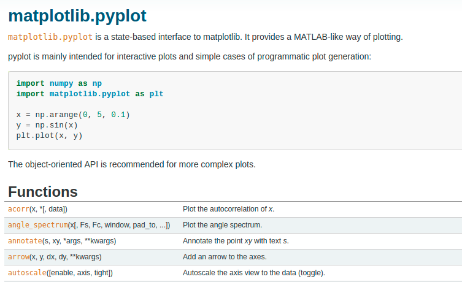

```python
import matplotlib.pyplot as plt
```

# Dataset for visualization

- Load the dataset and save it as `df`

```python
# This dataset is of type dataframe. Let's assign this dataset to a variable, so that we can manipulate it freely.
df = pd.read_csv(str(data_dir)+"/"+ "diabetes.csv")
```

```python
print(type(df))  #<- a Pandas DataFrame!
```

```
<class 'pandas.core.frame.DataFrame'>
```

```python
print(len(df))   #<- returns the number of rows
```

```
768
```

# Subsetting data

- Create a subset of the data so that the variables needed are present
- Name this subset as `df_subset`

```python
df_subset = df[['DiabetesPedigreeFunction', 'Glucose', 'BloodPressure', 'Age', 'SkinThickness', 'BMI', 'Insulin', 'Outcome', 'Pregnancies']]
print(df_subset.head())
```

```
   DiabetesPedigreeFunction  Glucose  BloodPressure  Age  SkinThickness   BMI  Insulin  Outcome  Pregnancies
0                     0.627      148             72   50             35  33.6        0        1            6
1                     0.351       85             66   31             29  26.6        0        0            1
2                     0.672      183             64   32              0  23.3        0        1            8
3                     0.167       89             66   21             23  28.1       94        0            1
4                     2.288      137             40   33             35  43.1      168        1            0
```

- These variables are choosen because they illustrate the concepts best
- However, you should be able to work with (and visualize) all of your data

# Data reshaping: wide vs. long

- Talking about data reshaping usually refers to converting between what is called either **wide** or **long** data formats
  - **Wide** data is much more visually digestible, which is why it’s more common when using data from some type of report
  - **Long** data is much easier to work with in Pandas, and generally speaking in most data analysis and plotting tools

# Data reshaping: wide vs long (cont’d)

- **Wide data** often appears when the values are some type of aggregate (we will use the `mean` of groups)
- Let’s make a typical **wide dataframe** of two rows and eight columns that looks like this:

[figure not shown]

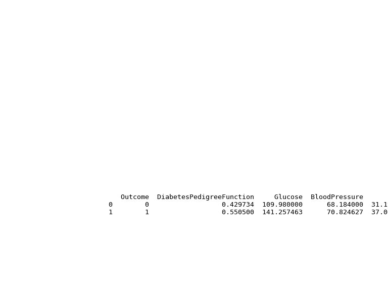

# Prepare data: group and summarize

- After grouping and summarizing data, create a summary dataset that will include the following:
  - Grouped data by `Target` variable
  - Mean value computed on the grouped data that includes the following variables:
    - `DiabetesPedigreeFunction`
    - `Glucose`
    - `BloodPressure`
    - `Age`
    - `SkinThickness`
    - `BMI`
    - `Insulin`

# Prepare data: group and summarize (cont’d)

```python
col_dict = df_subset.nunique().to_dict()
grouping_col = min(col_dict, key=col_dict.get)
# Group data by variable with min levels.
grouped = df_subset.groupby(grouping_col)
```

```python
# Compute mean on the listed variables using the grouped data.
df_grouped_mean = grouped.mean()[['DiabetesPedigreeFunction', 'Glucose', 'BloodPressure', 'Age', 'SkinThickness', 'BMI', 'Insulin']]
print(df_grouped_mean)
```

```
         DiabetesPedigreeFunction     Glucose  BloodPressure        Age  SkinThickness        BMI     Insulin
Outcome
0                        0.429734  109.980000      68.184000  31.190000      19.664000  30.304200   68.792000
1                        0.550500  141.257463      70.824627  37.067164      22.164179  35.142537  100.335821
```

# Prepare data: group and summarize (cont’d)

```python
# Reset index of the dataset.
df_grouped_mean = df_grouped_mean.reset_index()
print(df_grouped_mean)
```

```
   Outcome  DiabetesPedigreeFunction     Glucose  BloodPressure        Age  SkinThickness        BMI     Insulin
0        0                  0.429734  109.980000      68.184000  31.190000      19.664000  30.304200   68.792000
1        1                  0.550500  141.257463      70.824627  37.067164      22.164179  35.142537  100.335821
```

- This dataframe is considered **wide** because each variable has its own column
- It makes the table easier to present, but inconvenient to run analyses on or visualize

# Why long?

- Now convert this wide data to the **long format**
  - Leave the `categorical` variable and the mean values as is in their columns
  - All of other variables will appear as a single metric column
- This format is convenient to work with when running analysis and plot the data

[figure not shown]

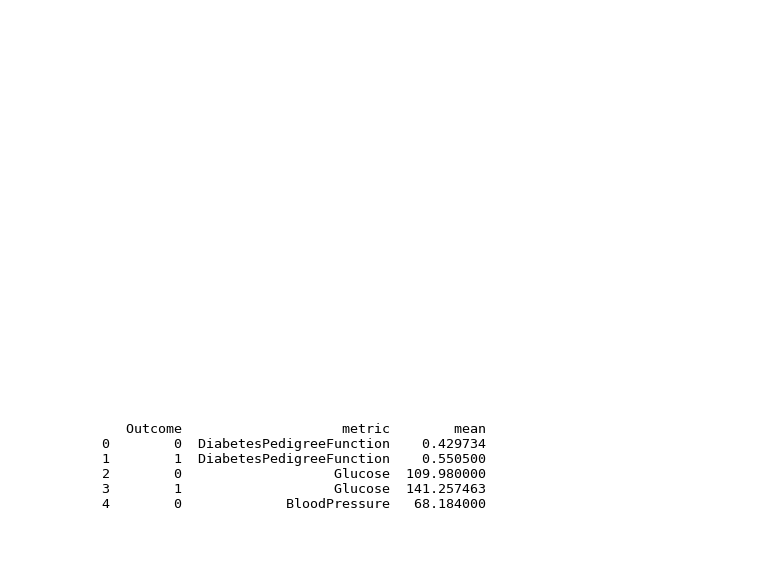

# Wide to long format: melt

- To **convert from wide to long format**, use the Pandas `melt` function with the following arguments:
  1. Wide dataframe
  2. Variable(s) that will be preserved as the `ids` of the data (like categorical variables)
  3. Name of the variable that will now contain the column names from the wide data selected to melt together
  4. Name of the column that will contain respective values corresponding to the melted columns

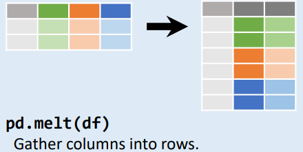

# Wide to long format: melt (cont’d)

```python
# Melt the wide data into long.
df_grouped_mean_long = pd.melt(df_grouped_mean,       #<- wide dataset
                                  id_vars = [grouping_col],     #<- identifying variable
                                  var_name = 'metric',      #<- contains col names of wide data
                                  value_name = 'mean')      #<- contains values from above columns
print(df_grouped_mean_long)
```

```
    Outcome                    metric        mean
0         0  DiabetesPedigreeFunction    0.429734
1         1  DiabetesPedigreeFunction    0.550500
2         0                   Glucose  109.980000
3         1                   Glucose  141.257463
4         0             BloodPressure   68.184000
5         1             BloodPressure   70.824627
6         0                       Age   31.190000
7         1                       Age   37.067164
8         0             SkinThickness   19.664000
9         1             SkinThickness   22.164179
10        0                       BMI   30.304200
11        1                       BMI   35.142537
12        0                   Insulin   68.792000
13        1                   Insulin  100.335821
```

# Long to wide format: pivot

- Convert the **long data back to wide** format with the `.pivot()` method
1. The `index` argument refers to what values will become the `ids` in the new dataframe
2. The `columns` argument refers to the column in which its values will be converted to column names
3. Lastly, supply the `values` argument to fill in the values of the wide data

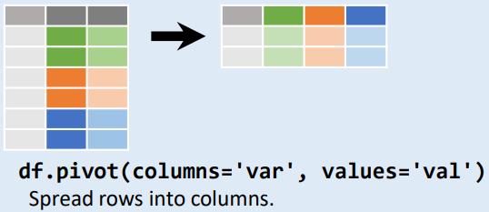

# Long to wide format: pivot (cont’d)

```python
# Melt the long data into wide.
df_grouped_mean_wide = df_grouped_mean_long.pivot(
                                                    index = [grouping_col],   #<- identifying variable
                                                    columns = 'metric', #<- col names of wide data
                                                    values = 'mean')    #<- values from above columns
print(df_grouped_mean_wide)
```

```
metric         Age        BMI  BloodPressure  DiabetesPedigreeFunction     Glucose     Insulin  SkinThickness
Outcome
0        31.190000  30.304200      68.184000                  0.429734  109.980000   68.792000      19.664000
1        37.067164  35.142537      70.824627                  0.550500  141.257463  100.335821      22.164179
```

# Module completion checklist

| Objective | Complete |
| --- | --- |
| Prepare data for visualization | **✔** |
| Create histograms, boxplots, and bar charts |  |

# Univariate plots

- Univariate plots are used to **visualize the distribution of a single variable**
- They are mainly used in the initial stages of EDA when we want to learn more about individual variables in our data
- They are also combined with other univariate plots to compare data distributions of different variables
- Univariate plots include the following popular graphs: `histogram`, `boxplot`, `density curve`, `dot plot`, `QQ plot`, and `bar plot`

# Univariate plots: histogram

- A histogram represents the **distribution of numerical data**
- The height of each bar has been calculated as the number of observations in that range
- Use `plt.hist()` to produce a basic histogram of any numeric variable

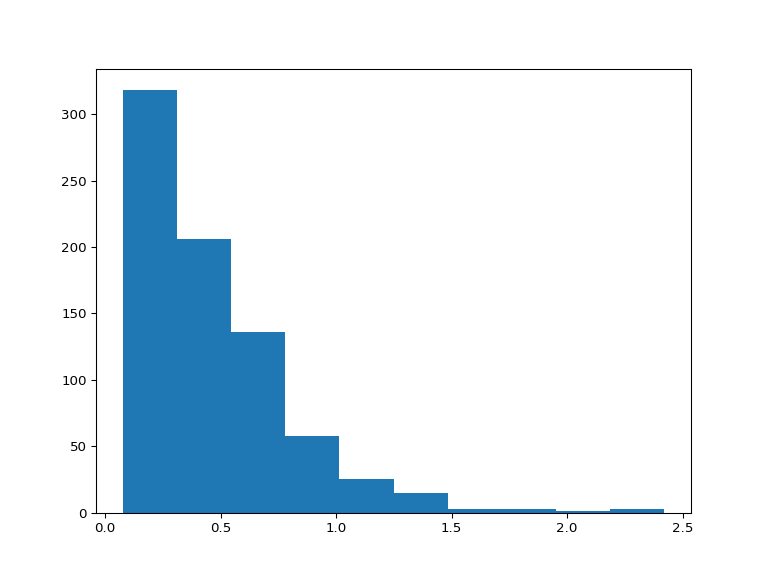

```python
plt.rcParams.update({'font.size': 15})
plt.hist(df_subset['DiabetesPedigreeFunction'])
plt.show()
```

# Univariate plots: histogram (cont’d)

- Bins represent the intervals in which to group the observations
- Control the number of bins with the `bins` parameter
- As the **number of bins increases**, the range of values each bin represents decreases, and so does the height of the bar

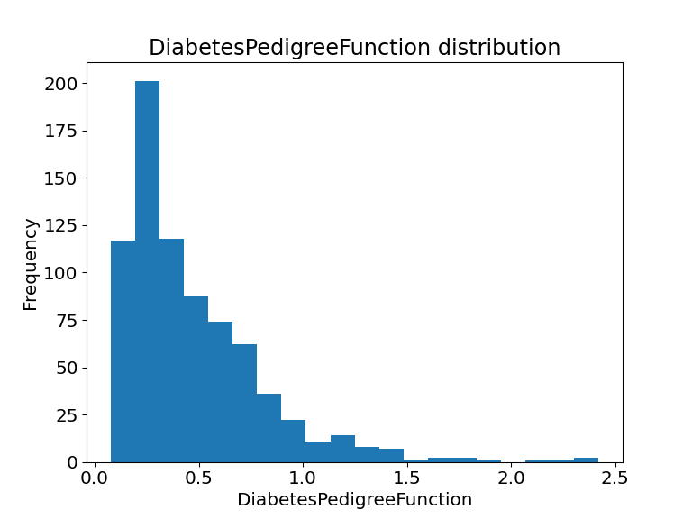

```python
plt.hist(df_subset['DiabetesPedigreeFunction'], bins = 20)
plt.xlabel('DiabetesPedigreeFunction')       #<- label x-axis
plt.ylabel('Frequency')      #<- label y-axis
plt.title('DiabetesPedigreeFunction distribution')      #<- add plot title
plt.show()
```

# Univariate plots: boxplot

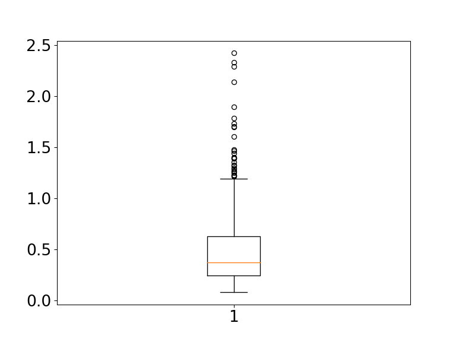

```python
plt.boxplot(df_subset['DiabetesPedigreeFunction'])
plt.show()
```

# Univariate plots: boxplot (cont’d)

- The orientation of the plot can be set to horizontal by setting `vert = False`
- Answer in chat: By looking at this boxplot, what can be told about the **`'DiabetesPedigreeFunction'`** distribution in the data?

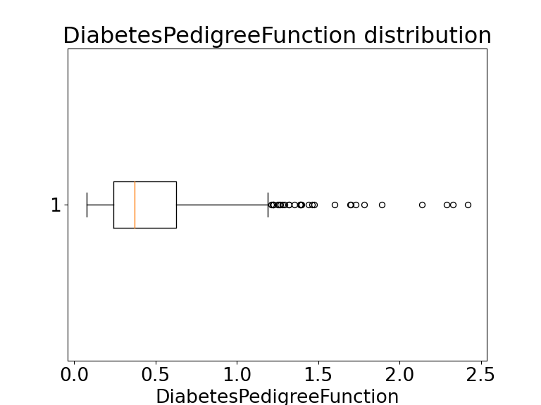

```python
plt.boxplot(df_subset['DiabetesPedigreeFunction'], vert = False)
plt.xlabel('DiabetesPedigreeFunction')       # label x-axis
plt.title('DiabetesPedigreeFunction distribution')      # add plot title
plt.show()
```

# Univariate plots: bar chart

- A bar chart is a plot where the height of each bar represents **the numeric value of a category**
- Use `plt.bar()` to produce a basic histogram of **any categorical variable**
- Bar charts are most commonly used when visualizing survey data or summary data
- The general syntax for creating a bar chart consists of 3 main variables:
  - position of the bars on the `axis`
  - height of the bars
  - names of categories that are used to label the bars

# Univariate plots: bar chart - cont’d

- When plotting bar charts of any complexity, the best type of data to use is **long data**
- First create a simple bar chart of the variable means using the `df_grouped_mean_long` data we created earlier

```python
print(df_grouped_mean_long.head())
```

[output not shown]

# Univariate plots: bar chart - cont’d

- Next, filter `'Outcome'` by a category and only keep two columns: `metric` and `mean`

```python
query = 'Outcome' + "==" + str('0')
df_true_means = df_grouped_mean_long.query(query)[['metric','mean']]
print(df_true_means)
```

[output not shown]

# Univariate plots: bar chart - cont’d

```python
bar_labels = df_true_means['metric']     #<- 1
bar_heights = df_true_means['mean']      #<- 2
num_bars = len(bar_heights)
bar_positions = np.arange(num_bars)      #<- 3
```

# Univariate plots: bar chart - cont’d

- Labels are tricky to fit sometimes, so either **adjust** the figure size or label orientation

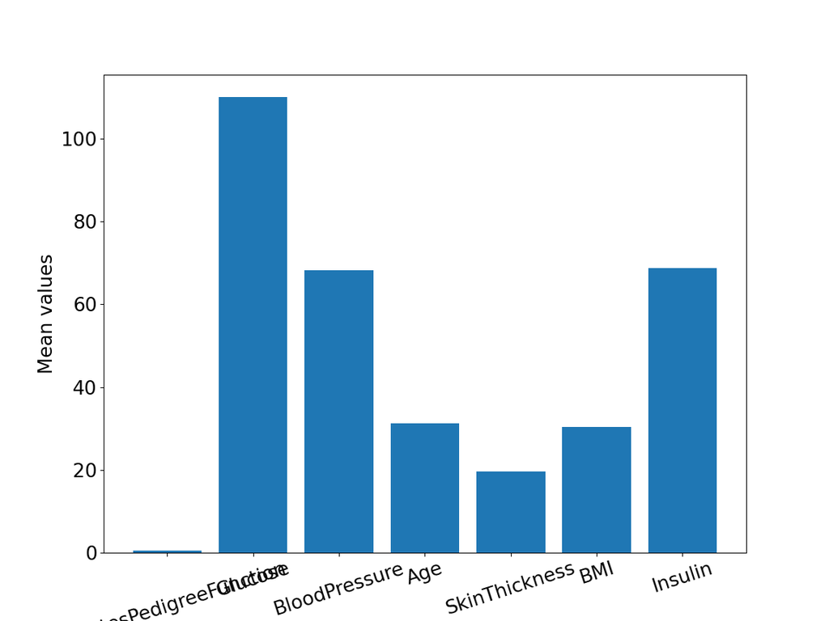

```python
plt.figure(figsize = (12, 9))
plt.bar(bar_positions, bar_heights)
plt.xticks(bar_positions,bar_labels,rotation = 18)
plt.ylabel('Mean values')
```

# Customize anything

- All possible style customizations are available in a `matplotlibrc` file
- [This sample (link)](https://matplotlib.org/users/customizing.html#a-sample-matplotlibrc-file) contains all of them, and any of those parameters can be passed to `rcParams` variable like we did earlier
- This sample contains a script of parameters and their default values
- Here’s a part of that file with a sample of all parameters for modifying the style of the `axes`

```
## ***************************************************************************
## * AXES                                                                    *
## ***************************************************************************
## Following are default face and edge colors, default tick sizes,
## default font sizes for tick labels, and so on.  See
## https://matplotlib.org/api/axes_api.html#module-matplotlib.axes
#axes.facecolor:     white   # axes background color
#axes.edgecolor:     black   # axes edge color
#axes.linewidth:     0.8     # edge line width
#axes.grid:          False   # display grid or not
#axes.grid.axis:     both    # which axis the grid should apply to
#axes.grid.which:    major   # grid lines at {major, minor, both} ticks
#axes.titlelocation: center  # alignment of the title: {left, right, center}
```

# Knowledge check

# Module completion checklist

| Objective | Complete |
| --- | --- |
| Prepare data for visualization | **✔** |
| Create histograms, boxplots, and bar charts | **✔** |

# Congratulations on completing this module!

You are now ready to try Tasks 1-13 in the Exercise for this topic